# Smoking Trends and Anti-Smoking Campaign Impact (1965–2019)

Hasan Basim

# Background

Smoking has long been one of the leading causes of preventable death in the United States.  
Anti smoking campaigns ranging from televised PSAs to large scale federal interventions were created to reduce smoking prevalence.  
This project investigates **whether major anti smoking campaigns correspond to measurable changes in national smoking rates**.

Key anti smoking eras studied:

- **1971:** Cigarette advertising banned on TV and radio
- **1998:** Master Settlement Agreement (large scale changes to advertising + funded campaigns)
- **2012:** FDA *Tips From Former Smokers* campaign

# Data

The dataset `cdc_smoking_trends_1965_2019.csv` contains annual smoking prevalence data for U.S. adults.

```r
dat <- read_csv("cdc_smoking_trends_1965_2019.csv") %>%
  mutate(
    era = case_when(
      year < 1971 ~ "Pre‑Ad Ban",
      year >= 1971 & year < 1998 ~ "Post‑Ad Ban",
      year >= 1998 & year < 2012 ~ "Post‑MSA",
      year >= 2012 ~ "Tips Campaign Era"
    )
  )
```

# Exploratory Figures

## Smoking prevalence over time

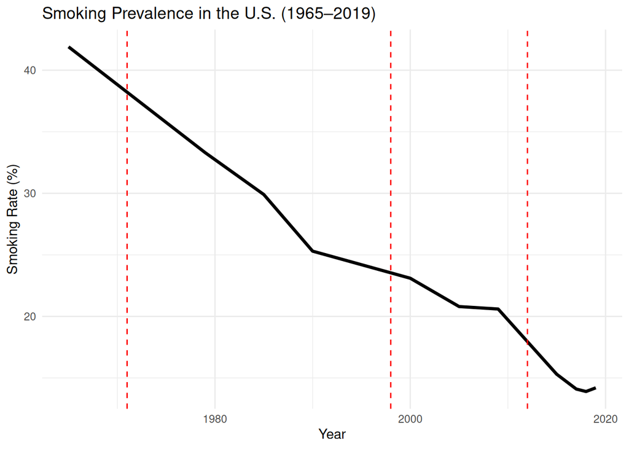

## Smoking trends by campaign era

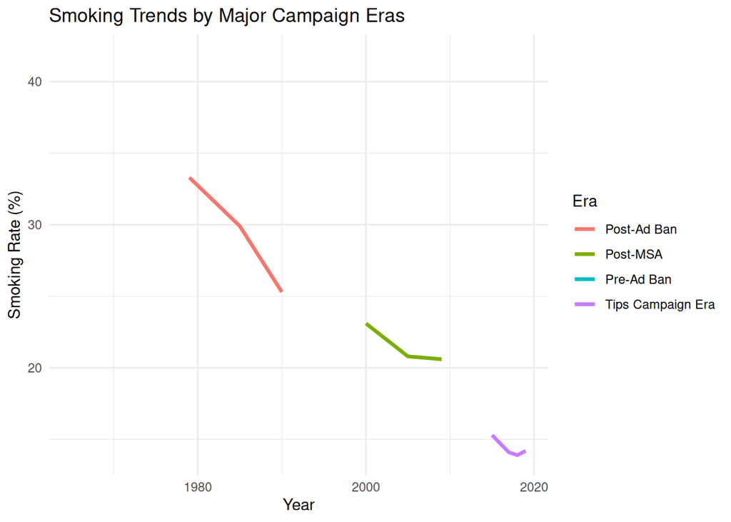